# IE48B_Final_Report

Yusuf Sina Öztürk

10/01/2022

### Summary

In this report, we handle with hourly solar power prediction data with different kind of temperature data. The task is a prediction task. We have to predict one day later with not knowing today’s data. Basically, we are going to predict 2 days ahead.

The way I follow to have a nice model to do my prediction is like that:

### Method

#### Reading the data, manipulation, adding seasonality variables and visualization

```r
data <- read.csv("production_with_weather_data.csv")
head(data)
```

```
##         date hour production DSWRF_surface_38_35 DSWRF_surface_38_35.25
## 1 2019-09-01    0     0.0000                   0                      0
## 2 2019-09-01    1     0.0000                   0                      0
## 3 2019-09-01    2     0.0000                   0                      0
## 4 2019-09-01    3     0.0000                   0                      0
## 5 2019-09-01    4     0.0000                   0                      0
## 6 2019-09-01    5     0.1912                   0                      0
##   DSWRF_surface_38_35.5 DSWRF_surface_38_35.75 DSWRF_surface_38_36
## 1                     0                      0                   0
## 2                     0                      0                   0
## 3                     0                      0                   0
## 4                     0                      0                   0
## 5                     0                      0                   0
## 6                     0                      0                   0
##   DSWRF_surface_38.25_35 DSWRF_surface_38.25_35.25 DSWRF_surface_38.25_35.5
```

[output cut: 573 more lines]

```r
data <- as.data.table(data)
data[,datetime:=ymd(date)+dhours(hour)]
data=data[order(datetime)] #to be sure that the data is ordered
```

visualize the target variable `production`

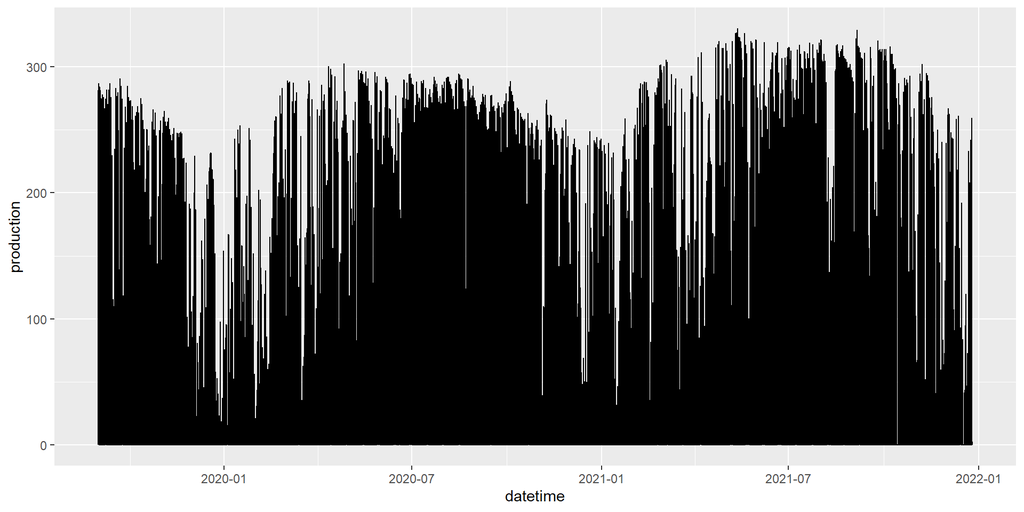

```r
ggplot(data ,aes(x=datetime,y=production)) + geom_line()
```

Adding trend, month and name of the day variables

```r
#adding trend variable
data[,trnd:=1:.N]

#adding name of the days and month variable
data[,w_day:=as.character(wday(datetime,label=T))]
data[,mon:=as.character(month(datetime,label=T))]
```

#### First Linear Regression Model

Now, we can create one linear regression model with using only seasonal terms.

```r
lm_base=lm(production~trnd+w_day+mon+as.factor(hour),data)
summary(lm_base)
```

```
##
## Call:
## lm(formula = production ~ trnd + w_day + mon + as.factor(hour),
##     data = data)
##
## Residuals:
##      Min       1Q   Median       3Q      Max
## -202.441  -20.046    1.221   28.172  108.915
##
## Coefficients:
##                     Estimate Std. Error t value Pr(>|t|)
## (Intercept)       -4.322e+00  1.931e+00  -2.238 0.025203 *
## trnd               4.562e-04  4.995e-05   9.132  < 2e-16 ***
## w_dayMon           1.271e+00  1.067e+00   1.191 0.233574
## w_daySat           7.199e-01  1.066e+00   0.675 0.499571
## w_daySun           4.217e+00  1.066e+00   3.954 7.70e-05 ***
## w_dayThu           1.244e+00  1.068e+00   1.164 0.244259
## w_dayTue           2.752e+00  1.067e+00   2.579 0.009902 **
## w_dayWed           5.218e-01  1.066e+00   0.489 0.624621
## monAug             2.001e+01  1.506e+00  13.284  < 2e-16 ***
## monDec            -3.433e+01  1.392e+00 -24.653  < 2e-16 ***
## monFeb            -1.444e+01  1.533e+00  -9.421  < 2e-16 ***
## monJan            -3.271e+01  1.502e+00 -21.775  < 2e-16 ***
## monJul             2.802e+01  1.502e+00  18.652  < 2e-16 ***
## monJun             2.092e+01  1.513e+00  13.825  < 2e-16 ***
## monMar            -1.142e+01  1.499e+00  -7.617 2.70e-14 ***
## monMay             1.740e+01  1.499e+00  11.601  < 2e-16 ***
## monNov            -1.699e+01  1.380e+00 -12.311  < 2e-16 ***
## monOct             1.760e+00  1.373e+00   1.282 0.199874
## monSep             1.138e+01  1.380e+00   8.251  < 2e-16 ***
## as.factor(hour)1  -1.566e-03  1.972e+00  -0.001 0.999367
## as.factor(hour)2  -2.005e-03  1.972e+00  -0.001 0.999189
## as.factor(hour)3   9.242e-04  1.972e+00   0.000 0.999626
## as.factor(hour)4   1.607e-02  1.972e+00   0.008 0.993499
## as.factor(hour)5   5.895e-01  1.972e+00   0.299 0.764975
## as.factor(hour)6   7.496e+00  1.972e+00   3.801 0.000144 ***
## as.factor(hour)7   3.803e+01  1.972e+00  19.287  < 2e-16 ***
## as.factor(hour)8   9.396e+01  1.972e+00  47.646  < 2e-16 ***
## as.factor(hour)9   1.521e+02  1.972e+00  77.122  < 2e-16 ***
## as.factor(hour)10  1.954e+02  1.972e+00  99.087  < 2e-16 ***
## as.factor(hour)11  2.182e+02  1.972e+00 110.663  < 2e-16 ***
## as.factor(hour)12  2.238e+02  1.972e+00 113.469  < 2e-16 ***
## as.factor(hour)13  2.133e+02  1.972e+00 108.175  < 2e-16 ***
## as.factor(hour)14  1.885e+02  1.972e+00  95.594  < 2e-16 ***
## as.factor(hour)15  1.460e+02  1.972e+00  74.052  < 2e-16 ***
## as.factor(hour)16  9.174e+01  1.972e+00  46.521  < 2e-16 ***
## as.factor(hour)17  4.021e+01  1.972e+00  20.389  < 2e-16 ***
## as.factor(hour)18  9.942e+00  1.972e+00   5.042 4.65e-07 ***
## as.factor(hour)19  1.013e+00  1.972e+00   0.514 0.607468
## as.factor(hour)20  5.405e-03  1.972e+00   0.003 0.997813
## as.factor(hour)21 -2.839e-03  1.972e+00  -0.001 0.998851
## as.factor(hour)22 -1.442e-02  1.972e+00  -0.007 0.994166
## as.factor(hour)23 -1.412e-02  1.972e+00  -0.007 0.994287
## ---
## Signif. codes:  0 '***' 0.001 '**' 0.01 '*' 0.05 '.' 0.1 ' ' 1
##
## Residual standard error: 40.53 on 20238 degrees of freedom
## Multiple R-squared:  0.8228, Adjusted R-squared:  0.8224
## F-statistic:  2292 on 41 and 20238 DF,  p-value: < 2.2e-16
```

As we can see hour and month variables have a strong importance in our base linear regression model. On the other hands, name of the week has not too much effect into the base model. However we are gong to keep it in our model.

Now we can add the given temperature data in our base model

#### Second Linear Regression Model

```r
lm_base_two = lm(production~. - datetime - date - hour + as.factor(hour), data)
summary(lm_base_two)
```

```
##
## Call:
## lm(formula = production ~ . - datetime - date - hour + as.factor(hour),
##     data = data)
##
## Residuals:
##      Min       1Q   Median       3Q      Max
## -203.545  -13.565    0.901   17.416  131.528
##
## Coefficients:
##                                       Estimate Std. Error t value Pr(>|t|)
## (Intercept)                         -1.788e+02  2.234e+01  -8.007 1.24e-15 ***
## DSWRF_surface_38_35                  2.439e-02  8.589e-03   2.839 0.004529 **
## DSWRF_surface_38_35.25               3.509e-04  8.167e-03   0.043 0.965728
## DSWRF_surface_38_35.5               -2.443e-02  8.410e-03  -2.905 0.003680 **
## DSWRF_surface_38_35.75               1.517e-02  1.001e-02   1.515 0.129742
## DSWRF_surface_38_36                  3.146e-02  8.618e-03   3.651 0.000262 ***
## DSWRF_surface_38.25_35              -1.198e-02  9.546e-03  -1.255 0.209524
## DSWRF_surface_38.25_35.25           -1.568e-02  1.126e-02  -1.393 0.163657
## DSWRF_surface_38.25_35.5             6.223e-02  1.193e-02   5.214 1.86e-07 ***
## DSWRF_surface_38.25_35.75           -4.218e-02  1.127e-02  -3.741 0.000183 ***
## DSWRF_surface_38.25_36               2.388e-02  9.147e-03   2.610 0.009049 **
## DSWRF_surface_38.5_35                6.568e-02  9.751e-03   6.736 1.68e-11 ***
## DSWRF_surface_38.5_35.25            -1.054e-01  1.100e-02  -9.586  < 2e-16 ***
## DSWRF_surface_38.5_35.5              6.535e-02  8.791e-03   7.435 1.09e-13 ***
## DSWRF_surface_38.5_35.75            -1.958e-02  1.037e-02  -1.888 0.059010 .
## DSWRF_surface_38.5_36                1.120e-02  1.019e-02   1.100 0.271538
## DSWRF_surface_38.75_35               8.841e-02  1.234e-02   7.167 7.92e-13 ***
## DSWRF_surface_38.75_35.25           -3.076e-02  1.418e-02  -2.169 0.030065 *
## DSWRF_surface_38.75_35.5            -1.859e-02  1.181e-02  -1.574 0.115610
## DSWRF_surface_38.75_35.75            7.611e-02  1.101e-02   6.910 4.98e-12 ***
## DSWRF_surface_38.75_36              -1.922e-02  1.122e-02  -1.713 0.086720 .
## DSWRF_surface_39_35                  3.968e-02  1.114e-02   3.563 0.000368 ***
## DSWRF_surface_39_35.25              -7.184e-02  1.643e-02  -4.371 1.24e-05 ***
## DSWRF_surface_39_35.5                2.454e-02  1.577e-02   1.556 0.119714
## DSWRF_surface_39_35.75               2.033e-02  1.422e-02   1.429 0.153029
## DSWRF_surface_39_36                 -1.426e-02  1.149e-02  -1.241 0.214628
## RH_2.m.above.ground_38_35           -1.322e-01  5.364e-02  -2.464 0.013760 *
## RH_2.m.above.ground_38_35.25         2.118e-01  5.089e-02   4.162 3.17e-05 ***
## RH_2.m.above.ground_38_35.5          8.054e-02  5.654e-02   1.424 0.154343
```

[output cut: 180 more lines]

```
## as.factor(hour)16                   -2.803e+00  1.856e+00  -1.510 0.131053
## as.factor(hour)17                   -3.748e+01  1.748e+00 -21.448  < 2e-16 ***
## as.factor(hour)18                   -5.037e+01  1.649e+00 -30.542  < 2e-16 ***
## as.factor(hour)19                   -4.376e+01  1.572e+00 -27.829  < 2e-16 ***
## as.factor(hour)20                   -3.298e+01  1.528e+00 -21.579  < 2e-16 ***
## as.factor(hour)21                   -2.612e+01  1.501e+00 -17.395  < 2e-16 ***
## as.factor(hour)22                    8.009e-01  1.443e+00   0.555 0.578839
## as.factor(hour)23                    3.954e-01  1.433e+00   0.276 0.782668
## ---
## Signif. codes:  0 '***' 0.001 '**' 0.01 '*' 0.05 '.' 0.1 ' ' 1
##
## Residual standard error: 29.4 on 20056 degrees of freedom
##   (7 observations deleted due to missingness)
## Multiple R-squared:  0.9076, Adjusted R-squared:  0.9066
## F-statistic:   912 on 216 and 20056 DF,  p-value: < 2.2e-16
```

Our R-squared value increased a lot by adding these temperature variables in our model. However, we have to consider that when we add new temperature variables in the model some of the seasonal terms lose their importance in the model.

We are not going to eliminate those not needed variables from the model because of the limited time.

Let us check how our lm_base_two model behave compared to actual values by getting predicted values.

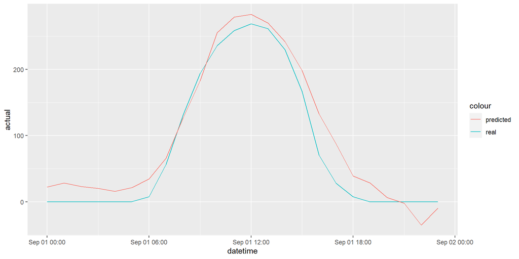

```r
tmp=copy(data)
tmp[,actual:=production]
tmp[,predicted:=predict(lm_base_two,tmp)]

ggplot(tmp[date=='2020-09-01'] ,aes(x=datetime)) +
  geom_line(aes(y=actual,color='real')) +
  geom_line(aes(y=predicted,color='predicted'))
```

Even this base model seems well fitted into our model.

#### EBLR Method

Now we can use EBLR approach to improve our model.

First, we need to get residuals to fit a tree.

```r
tmp[,residual:=actual-predicted]
```

We have some problems with not using variables while creating a regression tree so I have to create another data table named `tmp2`. Sorry for that!

```r
tmp2 <- tmp[,-c("date", "production","datetime","actual","predicted")]
```

So now we are able to get tree with using `rpart` function.

```r
fit_res_tree=rpart(residual~.,tmp2,
                   control=rpart.control(cp=0,maxdepth=4))
```

Let me visualize our regression tree.

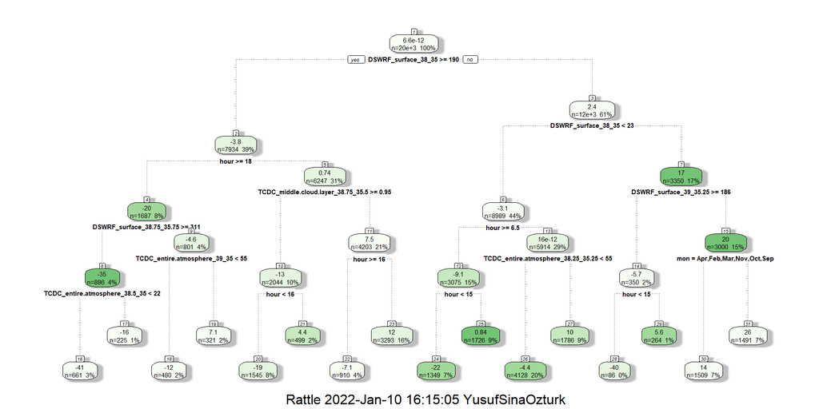

```r
fancyRpartPlot(fit_res_tree)
```

So the most right tree leaf node has the biggest value and has 7% percentage. Therefore, we are going to use that leaf node in our first iteration.

Adding those variables to the dataset, to represent that leaf node.

```r
tmp[,DSWRF_38_35_depth_1:=as.numeric(DSWRF_surface_38_35 < 190)]
tmp[,DSWRF_38_35_depth_2:=as.numeric(DSWRF_surface_38_35 >= 23)]
tmp[,DSWRF_39_35.25_depth_3:=as.numeric(DSWRF_surface_39_35.25 < 186)]
tmp[,month_depth_4:=as.numeric(!mon %in% c('Apr','Feb','Mar','Nov','Oct','Sep'))]
```

Now, we can create another linear regression model with that leaf node represented in it.

```r
lm_base_two_iter1=lm(production~. - datetime - date - hour + as.factor(hour) -residual - predicted - actual - DSWRF_38_35_depth_1 - DSWRF_38_35_depth_2 - DSWRF_39_35.25_depth_3 -month_depth_4
                     + DSWRF_38_35_depth_1:DSWRF_38_35_depth_2:DSWRF_39_35.25_depth_3:month_depth_4
                       ,tmp)

summary(lm_base_two_iter1)
```

```
##
## Call:
## lm(formula = production ~ . - datetime - date - hour + as.factor(hour) -
##     residual - predicted - actual - DSWRF_38_35_depth_1 - DSWRF_38_35_depth_2 -
##     DSWRF_39_35.25_depth_3 - month_depth_4 + DSWRF_38_35_depth_1:DSWRF_38_35_depth_2:DSWRF_39_35.25_depth_3:month_depth_4,
##     data = tmp)
##
## Residuals:
##      Min       1Q   Median       3Q      Max
## -203.453  -13.135    0.922   16.072  128.847
##
## Coefficients:
##                                                                                Estimate
## (Intercept)                                                                  -1.329e+02
## DSWRF_surface_38_35                                                           3.272e-02
## DSWRF_surface_38_35.25                                                       -3.910e-03
## DSWRF_surface_38_35.5                                                        -1.853e-02
## DSWRF_surface_38_35.75                                                        6.463e-03
## DSWRF_surface_38_36                                                           4.325e-02
## DSWRF_surface_38.25_35                                                       -2.244e-03
## DSWRF_surface_38.25_35.25                                                    -2.458e-02
## DSWRF_surface_38.25_35.5                                                      7.591e-02
## DSWRF_surface_38.25_35.75                                                    -4.535e-02
## DSWRF_surface_38.25_36                                                        1.851e-02
## DSWRF_surface_38.5_35                                                         6.648e-02
## DSWRF_surface_38.5_35.25                                                     -9.791e-02
## DSWRF_surface_38.5_35.5                                                       5.731e-02
## DSWRF_surface_38.5_35.75                                                     -1.519e-02
## DSWRF_surface_38.5_36                                                         3.872e-03
## DSWRF_surface_38.75_35                                                        8.803e-02
## DSWRF_surface_38.75_35.25                                                    -3.201e-02
## DSWRF_surface_38.75_35.5                                                     -2.035e-02
## DSWRF_surface_38.75_35.75                                                     7.881e-02
## DSWRF_surface_38.75_36                                                       -1.362e-02
## DSWRF_surface_39_35                                                           3.250e-02
## DSWRF_surface_39_35.25                                                       -4.893e-02
## DSWRF_surface_39_35.5                                                         2.431e-02
## DSWRF_surface_39_35.75                                                        2.295e-02
## DSWRF_surface_39_36                                                          -2.371e-02
## RH_2.m.above.ground_38_35                                                    -2.157e-01
```

[output cut: 1059 more lines]

```
## as.factor(hour)17                                                            ***
## as.factor(hour)18                                                            ***
## as.factor(hour)19                                                            ***
## as.factor(hour)20                                                            ***
## as.factor(hour)21                                                            ***
## as.factor(hour)22
## as.factor(hour)23
## DSWRF_38_35_depth_1:DSWRF_38_35_depth_2:DSWRF_39_35.25_depth_3:month_depth_4 ***
## ---
## Signif. codes:  0 '***' 0.001 '**' 0.01 '*' 0.05 '.' 0.1 ' ' 1
##
## Residual standard error: 27.94 on 20055 degrees of freedom
##   (7 observations deleted due to missingness)
## Multiple R-squared:  0.9165, Adjusted R-squared:  0.9156
## F-statistic:  1015 on 217 and 20055 DF,  p-value: < 2.2e-16
```

So our R-squared value increased around one percent. We can do second iteration with using the same EBLR approach

First need to see how fitted our second model:

```r
tmp[,predicted:=predict(lm_base_two_iter1,tmp)]
head(tmp)
```

```
##          date hour production DSWRF_surface_38_35 DSWRF_surface_38_35.25
## 1: 2019-09-01    0     0.0000                   0                      0
## 2: 2019-09-01    1     0.0000                   0                      0
## 3: 2019-09-01    2     0.0000                   0                      0
## 4: 2019-09-01    3     0.0000                   0                      0
## 5: 2019-09-01    4     0.0000                   0                      0
## 6: 2019-09-01    5     0.1912                   0                      0
##    DSWRF_surface_38_35.5 DSWRF_surface_38_35.75 DSWRF_surface_38_36
## 1:                     0                      0                   0
## 2:                     0                      0                   0
## 3:                     0                      0                   0
## 4:                     0                      0                   0
## 5:                     0                      0                   0
## 6:                     0                      0                   0
##    DSWRF_surface_38.25_35 DSWRF_surface_38.25_35.25 DSWRF_surface_38.25_35.5
```

[output cut: 587 more lines]

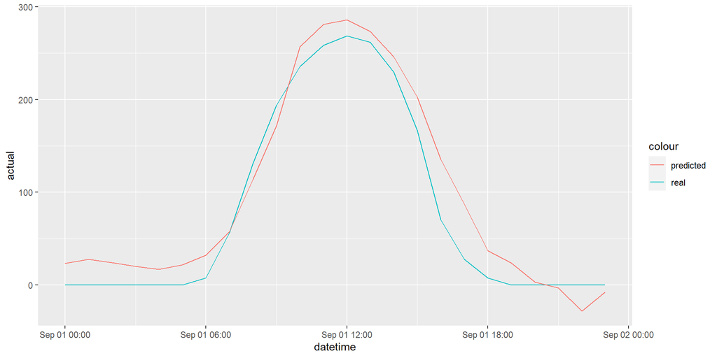

```r
ggplot(tmp[date=='2020-09-01'] ,aes(x=datetime)) +
  geom_line(aes(y=actual,color='real')) +
  geom_line(aes(y=predicted,color='predicted'))
```

Now we can get new residuals.

```r
tmp[,residual:=actual-predicted]
```

Again we have some problems with not using variables while creating a regression tree so I have to create another data table named `tmp3`

```r
tmp3 <- tmp[,-c("date", "production","datetime","actual","predicted", "DSWRF_39_35.25_depth_3", "month_depth_4", "DSWRF_38_35_depth_1","DSWRF_38_35_depth_2")]
```

Now, I can get tree with using `rpart` function

```r
fit_res_tree_iter2=rpart(residual~.,tmp3,
                   control=rpart.control(cp=0,maxdepth=4))
```

Let me visualize our regression tree.

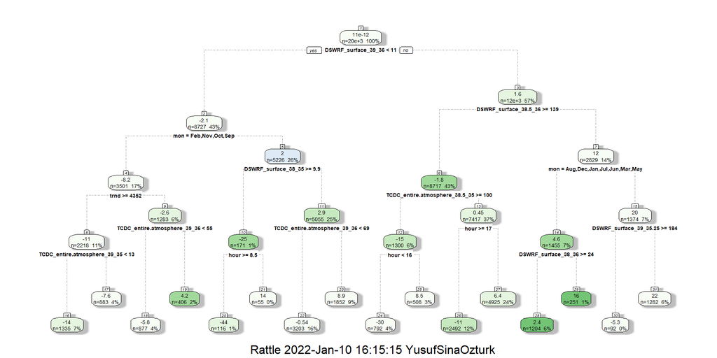

```r
fancyRpartPlot(fit_res_tree_iter2)
```

Adding those variables to the dataset, to represent that leaf node.

```r
tmp[,iter_2_depth_1:=as.numeric(DSWRF_surface_39_36 >= 11)]
tmp[,iter_2_depth_2:=as.numeric(DSWRF_surface_38.5_36 < 139)]
tmp[,iter_2_depth_3:=as.numeric(!mon %in% c('Aug','Dec','Jan','Jul','Jun','Mar','May'))]
tmp[,iter_2_depth_4:=as.numeric(DSWRF_surface_39_35.25 < 184)]
```

Now, we can create another linear regression model with that leaf node represented in it.

```r
lm_base_two_iter2=lm(production~. - datetime - date - hour + as.factor(hour) -residual - predicted - actual
                     - DSWRF_38_35_depth_1 - DSWRF_38_35_depth_2 - DSWRF_39_35.25_depth_3 -month_depth_4
                     - iter_2_depth_1 - iter_2_depth_2- iter_2_depth_3- iter_2_depth_4
                     + DSWRF_38_35_depth_1:DSWRF_38_35_depth_2:DSWRF_39_35.25_depth_3:month_depth_4
                     + iter_2_depth_1:iter_2_depth_2:iter_2_depth_3:iter_2_depth_4
                     ,tmp)

summary(lm_base_two_iter2)
```

```
##
## Call:
## lm(formula = production ~ . - datetime - date - hour + as.factor(hour) -
##     residual - predicted - actual - DSWRF_38_35_depth_1 - DSWRF_38_35_depth_2 -
##     DSWRF_39_35.25_depth_3 - month_depth_4 - iter_2_depth_1 -
##     iter_2_depth_2 - iter_2_depth_3 - iter_2_depth_4 + DSWRF_38_35_depth_1:DSWRF_38_35_depth_2:DSWRF_39_35.25_depth_3:month_depth_4 +
##     iter_2_depth_1:iter_2_depth_2:iter_2_depth_3:iter_2_depth_4,
##     data = tmp)
##
## Residuals:
##      Min       1Q   Median       3Q      Max
## -208.172  -12.104    0.564   14.828  127.466
##
## Coefficients:
##                                                                                Estimate
## (Intercept)                                                                  -1.202e+02
## DSWRF_surface_38_35                                                           3.014e-02
## DSWRF_surface_38_35.25                                                       -1.446e-03
## DSWRF_surface_38_35.5                                                        -1.967e-02
## DSWRF_surface_38_35.75                                                        5.276e-03
## DSWRF_surface_38_36                                                           4.270e-02
## DSWRF_surface_38.25_35                                                        3.985e-03
## DSWRF_surface_38.25_35.25                                                    -2.767e-02
## DSWRF_surface_38.25_35.5                                                      8.198e-02
## DSWRF_surface_38.25_35.75                                                    -4.869e-02
## DSWRF_surface_38.25_36                                                        2.151e-02
## DSWRF_surface_38.5_35                                                         6.871e-02
## DSWRF_surface_38.5_35.25                                                     -8.815e-02
## DSWRF_surface_38.5_35.5                                                       5.156e-02
## DSWRF_surface_38.5_35.75                                                     -1.209e-02
## DSWRF_surface_38.5_36                                                         2.990e-03
## DSWRF_surface_38.75_35                                                        8.779e-02
## DSWRF_surface_38.75_35.25                                                    -3.467e-02
## DSWRF_surface_38.75_35.5                                                     -1.816e-02
## DSWRF_surface_38.75_35.75                                                     7.715e-02
## DSWRF_surface_38.75_36                                                       -1.345e-02
## DSWRF_surface_39_35                                                           3.265e-02
## DSWRF_surface_39_35.25                                                       -4.760e-02
## DSWRF_surface_39_35.5                                                         2.862e-02
## DSWRF_surface_39_35.75                                                        2.210e-02
```

[output cut: 1066 more lines]

```
## as.factor(hour)18                                                            ***
## as.factor(hour)19                                                            ***
## as.factor(hour)20                                                            ***
## as.factor(hour)21                                                            ***
## as.factor(hour)22
## as.factor(hour)23
## DSWRF_38_35_depth_1:DSWRF_38_35_depth_2:DSWRF_39_35.25_depth_3:month_depth_4 ***
## iter_2_depth_1:iter_2_depth_2:iter_2_depth_3:iter_2_depth_4                  ***
## ---
## Signif. codes:  0 '***' 0.001 '**' 0.01 '*' 0.05 '.' 0.1 ' ' 1
##
## Residual standard error: 27.01 on 20054 degrees of freedom
##   (7 observations deleted due to missingness)
## Multiple R-squared:  0.922,  Adjusted R-squared:  0.9212
## F-statistic:  1088 on 218 and 20054 DF,  p-value: < 2.2e-16
```

Our R-squared value increased by 0.5% but we can do one more iteration.

Need to see how fitted our second iteration.

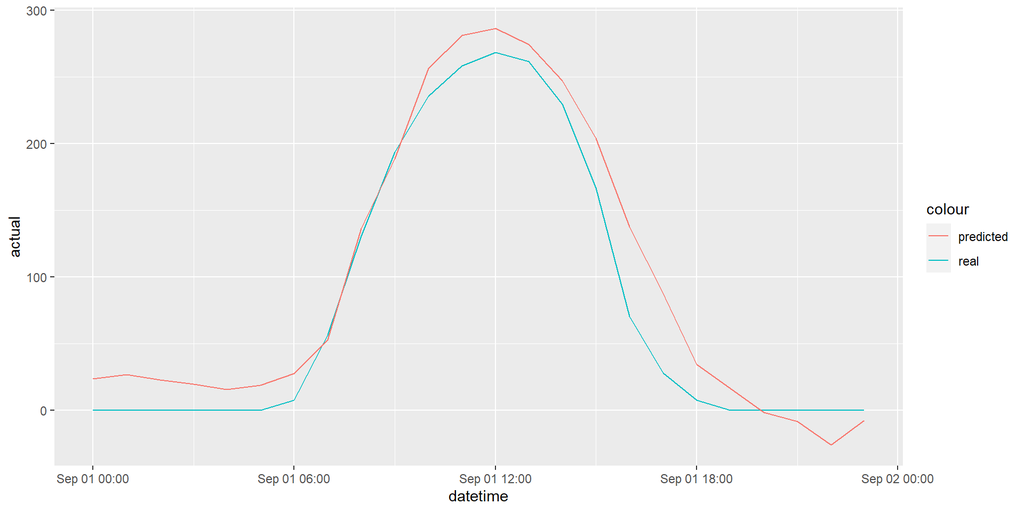

```r
tmp[,predicted:=predict(lm_base_two_iter2,tmp)]

ggplot(tmp[date=='2020-09-01'] ,aes(x=datetime)) +
  geom_line(aes(y=actual,color='real')) +
  geom_line(aes(y=predicted,color='predicted'))
```

Now we can get new residuals.

```r
tmp[,residual:=actual-predicted]
```

Again we have some problems with not using variables while creating a regression tree so I have to create another data table named `tmp4`

```r
tmp4 <- tmp[,-c("date", "production","datetime","actual","predicted", "DSWRF_39_35.25_depth_3", "month_depth_4", "DSWRF_38_35_depth_1","DSWRF_38_35_depth_2","iter_2_depth_1","iter_2_depth_2","iter_2_depth_3","iter_2_depth_4")]
```

Now, I can get tree with using `rpart` function

[figure not shown]

```r
fit_res_tree_iter3=rpart(residual~.,tmp4,
                         control=rpart.control(cp=0,maxdepth=4))

fancyRpartPlot(fit_res_tree_iter3)
```

Adding those variables to the dataset, to represent that leaf node.

```r
tmp[,iter_3_depth_1:=as.numeric(RH_2.m.above.ground_38.25_36 < 96)]
tmp[,iter_3_depth_2:=as.numeric(TMP_2.m.above.ground_38.25_35 >= 274)]
tmp[,iter_3_depth_3:=as.numeric(hour<17)]
tmp[,iter_3_depth_4:=as.numeric(TCDC_middle.cloud.layer_38.75_35.75 < 0.65)]
```

Now, we can create another linear regression model with that leaf node represented in it.

```r
lm_base_two_iter3=lm(production~. - datetime - date - hour + as.factor(hour) -residual - predicted - actual
                     - DSWRF_38_35_depth_1 - DSWRF_38_35_depth_2 - DSWRF_39_35.25_depth_3 -month_depth_4
                     - iter_2_depth_1 - iter_2_depth_2- iter_2_depth_3- iter_2_depth_4
                     - iter_3_depth_1 - iter_3_depth_2- iter_3_depth_3- iter_3_depth_4
                     + DSWRF_38_35_depth_1:DSWRF_38_35_depth_2:DSWRF_39_35.25_depth_3:month_depth_4
                     + iter_2_depth_1:iter_2_depth_2:iter_2_depth_3:iter_2_depth_4
                     + iter_3_depth_1:iter_3_depth_2:iter_3_depth_3:iter_3_depth_4
                     ,tmp)

summary(lm_base_two_iter3)
```

```
##
## Call:
## lm(formula = production ~ . - datetime - date - hour + as.factor(hour) -
##     residual - predicted - actual - DSWRF_38_35_depth_1 - DSWRF_38_35_depth_2 -
##     DSWRF_39_35.25_depth_3 - month_depth_4 - iter_2_depth_1 -
##     iter_2_depth_2 - iter_2_depth_3 - iter_2_depth_4 - iter_3_depth_1 -
##     iter_3_depth_2 - iter_3_depth_3 - iter_3_depth_4 + DSWRF_38_35_depth_1:DSWRF_38_35_depth_2:DSWRF_39_35.25_depth_3:month_depth_4 +
##     iter_2_depth_1:iter_2_depth_2:iter_2_depth_3:iter_2_depth_4 +
##     iter_3_depth_1:iter_3_depth_2:iter_3_depth_3:iter_3_depth_4,
##     data = tmp)
##
## Residuals:
##      Min       1Q   Median       3Q      Max
## -193.711  -12.555    0.566   14.710  132.003
##
## Coefficients:
##                                                                                Estimate
## (Intercept)                                                                  -7.570e+01
## DSWRF_surface_38_35                                                           3.346e-02
## DSWRF_surface_38_35.25                                                       -1.030e-02
## DSWRF_surface_38_35.5                                                        -2.331e-02
## DSWRF_surface_38_35.75                                                        1.541e-02
## DSWRF_surface_38_36                                                           3.886e-02
## DSWRF_surface_38.25_35                                                        6.324e-03
## DSWRF_surface_38.25_35.25                                                    -2.862e-02
## DSWRF_surface_38.25_35.5                                                      7.886e-02
## DSWRF_surface_38.25_35.75                                                    -4.309e-02
## DSWRF_surface_38.25_36                                                        2.080e-02
## DSWRF_surface_38.5_35                                                         6.159e-02
## DSWRF_surface_38.5_35.25                                                     -7.766e-02
## DSWRF_surface_38.5_35.5                                                       4.544e-02
## DSWRF_surface_38.5_35.75                                                     -1.033e-02
## DSWRF_surface_38.5_36                                                         3.918e-03
## DSWRF_surface_38.75_35                                                        8.386e-02
## DSWRF_surface_38.75_35.25                                                    -3.023e-02
## DSWRF_surface_38.75_35.5                                                     -1.506e-02
## DSWRF_surface_38.75_35.75                                                     7.214e-02
## DSWRF_surface_38.75_36                                                       -1.434e-02
## DSWRF_surface_39_35                                                           2.951e-02
## DSWRF_surface_39_35.25                                                       -4.532e-02
```

[output cut: 1073 more lines]

```
## as.factor(hour)19                                                            ***
## as.factor(hour)20                                                            ***
## as.factor(hour)21                                                            ***
## as.factor(hour)22                                                            ***
## as.factor(hour)23                                                            ***
## DSWRF_38_35_depth_1:DSWRF_38_35_depth_2:DSWRF_39_35.25_depth_3:month_depth_4 ***
## iter_2_depth_1:iter_2_depth_2:iter_2_depth_3:iter_2_depth_4                  ***
## iter_3_depth_1:iter_3_depth_2:iter_3_depth_3:iter_3_depth_4                  ***
## ---
## Signif. codes:  0 '***' 0.001 '**' 0.01 '*' 0.05 '.' 0.1 ' ' 1
##
## Residual standard error: 26.26 on 20053 degrees of freedom
##   (7 observations deleted due to missingness)
## Multiple R-squared:  0.9263, Adjusted R-squared:  0.9255
## F-statistic:  1151 on 219 and 20053 DF,  p-value: < 2.2e-16
```

#### Prediction

Now time to do prediction.

To compare my prediction, I am going to predict the last 2 days production values to calculate WMAPE value.

Also because we have limited time to finish this task, I am going to take all the temperature data (naively) from 2 days ago directly.

```r
testdata <- tmp[c(20233:20280),]

traindata <- copy(tmp)
traindata <- as.data.frame(traindata)
for (i in 1:48){
  for (j in 3: 197){
    traindata[(20232 + i), j] <- traindata[(20184 + i),j]
  }
}
```

```r
tmp[,predicted:=predict(lm_base_two_iter3,tmp)]
predicted_values <- tmp$predicted[20233:20280]
predicted_values
```

```
##  [1] -11.8696386 -12.2164284 -12.2042819 -12.8303077 -21.7961641 -22.8272383
##  [7] -18.7779682  -3.8998725  32.7027952  77.6827666 107.5481442 140.4376505
## [13] 153.1513686 149.7036481 131.9199980  94.5326918  46.4632369  -5.3129102
## [19]   8.6778207   7.5392177  15.3271415  19.4265748  13.7255706  12.7227049
## [25]   2.9397286   4.2822609   6.4627254   6.8124161   6.3108646   8.1108836
## [31]  14.8864948  30.1504871  65.0021012 113.3139502 153.0924928 180.9699294
## [37] 188.0223335 178.3147391 175.2728977 129.3708665          NA   0.1780546
## [43]  13.2632333   7.6290570  12.1385533  16.2306752   9.0591560   9.9667015
```

Because it is not able to have negative production we need to fix those values into zero.

```r
predicted_values[is.na(predicted_values)] = 0
for (i in 1:48){
  if(predicted_values[i] < 0){
    predicted_values[i] <- 0
  }
}
predicted_values
```

```
##  [1]   0.0000000   0.0000000   0.0000000   0.0000000   0.0000000   0.0000000
##  [7]   0.0000000   0.0000000  32.7027952  77.6827666 107.5481442 140.4376505
## [13] 153.1513686 149.7036481 131.9199980  94.5326918  46.4632369   0.0000000
## [19]   8.6778207   7.5392177  15.3271415  19.4265748  13.7255706  12.7227049
## [25]   2.9397286   4.2822609   6.4627254   6.8124161   6.3108646   8.1108836
## [31]  14.8864948  30.1504871  65.0021012 113.3139502 153.0924928 180.9699294
## [37] 188.0223335 178.3147391 175.2728977 129.3708665   0.0000000   0.1780546
## [43]  13.2632333   7.6290570  12.1385533  16.2306752   9.0591560   9.9667015
```

```r
actual_values <- testdata$production[1:48]
actual_values
```

```
##  [1]   0.000000   0.000000   0.000000   0.000000   0.000000   0.000000
##  [7]   0.126852   0.574244  10.321740  59.713520 145.837200 218.552200
## [13] 241.952500 238.965100 202.645300 125.340000  43.054350   0.994444
## [19]   0.000000   0.000000   0.000000   0.000000   0.000000   0.000000
## [25]   0.000000   0.000000   0.000000   0.000000   0.000000   0.000000
## [31]   0.056599   1.483106  33.958400 117.153200 195.276600 242.458700
## [37] 259.184100 250.315300 208.939500 132.541200  46.846580   3.035200
## [43]   0.000000   0.000000   0.000000   0.000000   0.000000   0.000000
```

Now we can calculate our WMAPE value for our model.

#### WMAPE Calculation

Because our task is to predict one day later with knowing one day before data. While we are calcultaing WMAPE, we need to use only last 24 data of the actual and predicted values

```r
numerator = 0
denom = 0

for ( i in 25:48){
  numerator = numerator + actual_values[i] - predicted_values[i]
  denom = denom + actual_values[i]
}

WMAPE = numerator / denom
WMAPE
```

```
## [1] 0.1069358
```

### Discussion

In order to improve our prediction:

- We can do more iterations have better model.
- We can also predict the temperature values. Not only getting the lagged values. Meteorology data can also help us about that.
- While we are choosing the node from the regression tree, we can do more analysis. I basicaly choose the highest values and highest percentage one.